# Lecture #11: Tangent Line Approximation & Newton’s Method

MATH 145 – Calculus I

Torin Quinlivan

tquinlivan@knox.edu

Knox College

October 7, 2025

## Local Linearization

Recall that: If $f(x)$ is differentiable at $x = a$, the local linearization (or tangent line approximation) to $f(x)$ near $x = a$ is the function
$$y = L(x) \approx f(a) + f'(a)(x - a)$$

If $f(x)$ is differentiable at $x = a$, you can approximate it by its tangent line.

## Example: Linear Approximation

**Example:** Estimate $\sqrt{36.1}$ using linear approximation.

**Example:** Estimate $f(2.3)$ using $x=2$ for $f(x) = x^3 e^{-x^2}$, if we know that $f'(x) = e^{-x^2} (3x^2 - 2x^4)$.

**Example:** Suppose that $g(x)$ is a function with $g(130) = 46$ and $f'(130) = 2$. Estimate $g(125.5)$.

## Linear Approximation and Algebra

**Question:** Where does the linear approximation $l(x) = f(a) + f'(a) (x - a)$ intersect the $x$-axis?

Can we make this approximation better by moving the line? Can we *iterate* this?

## Linear Approximation and Algebra

This iterative algorithm is known as Newton’s Method:

**Newton’s Method** for approximating solutions to $f(x) = 0$:

## Example: Newton’s Method

**Example:** Estimate the roots of $f(x) = x^2 - 2$ using Newton’s method.

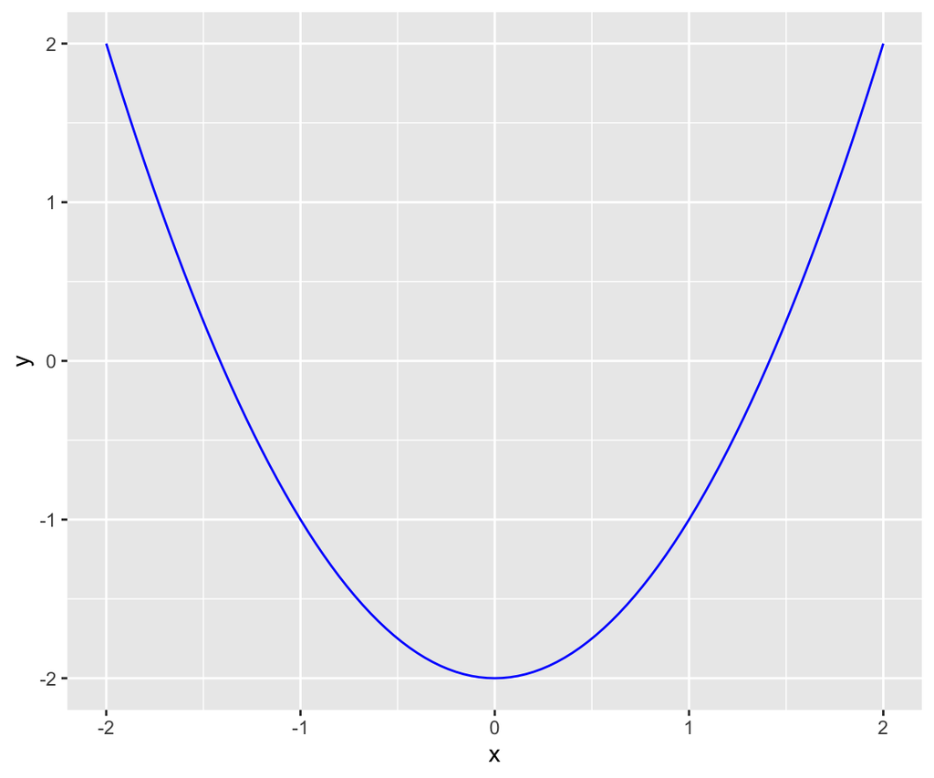

## Example: Newton’s Method

**Example:** Estimate the roots of $f(x) = -x^2 + 2x + 2$ using Newton’s method.

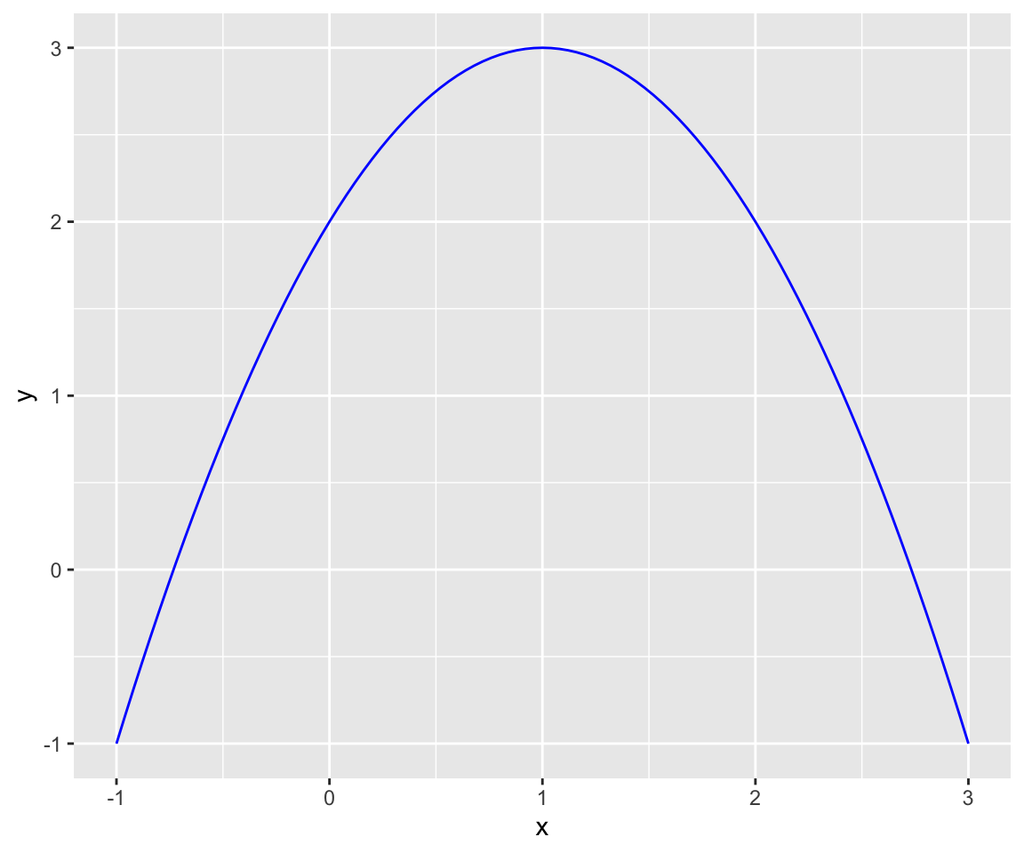

## Example: Newton’s Method

**Example:** Estimate the roots of $f(x) = x^3 - x^2 - 2x + 1$ using Newton’s method.

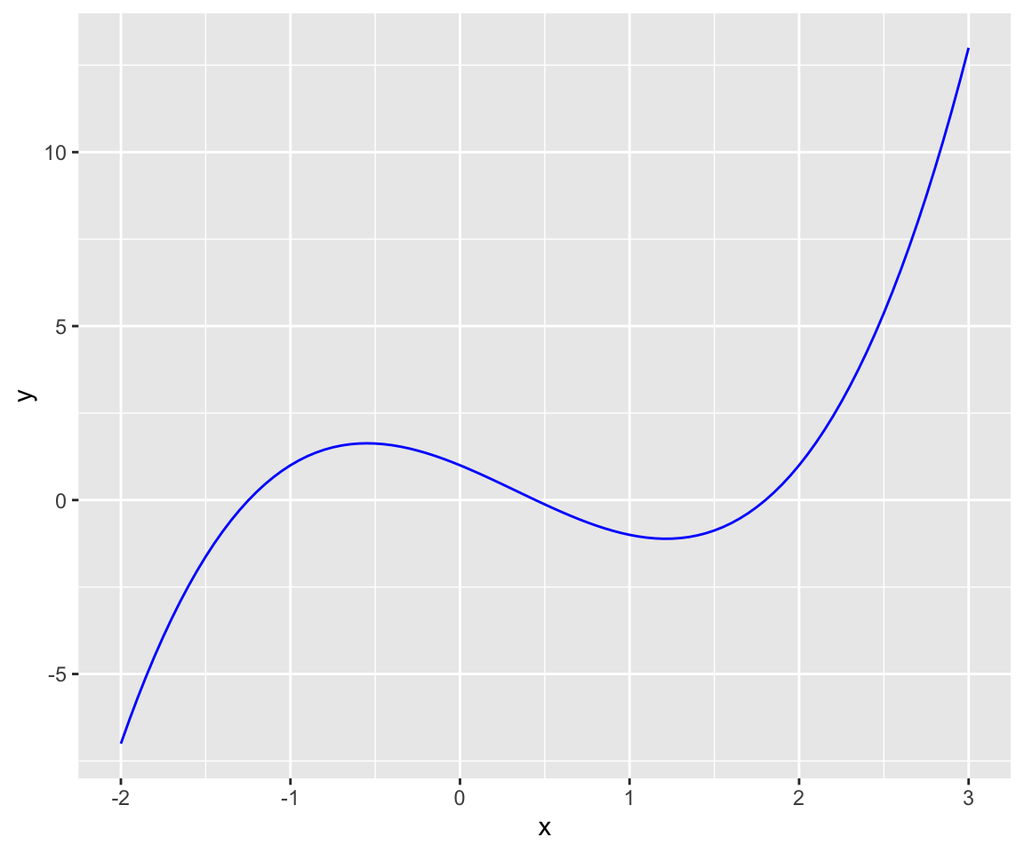